# Working with fMRI data using R

### Recap: what is fMRI?

MRI is an imaging technique, with which we can take scans of muscles, bones, brains,… fMRI is when we repeatedly take MRI scans of the brain. This allows us to see the brain *in action* when it’s performing tasks etc.

Imagine a subject listening to broadband noise for 15 seconds, and then listening to silence for 15 seconds, and repeat this for 10 times while taking brain scans every 3 seconds. Afterwards, we can compare the scans during silence with the scans during music, and end up with an image like the following from [Okada et al., 2013](http://journals.plos.org/plosone/article?id=10.1371/journal.pone.0068959). The brain image in the back is a structural MRI, the red blobs are the parts of the brain that show a significant difference between the two conditions.

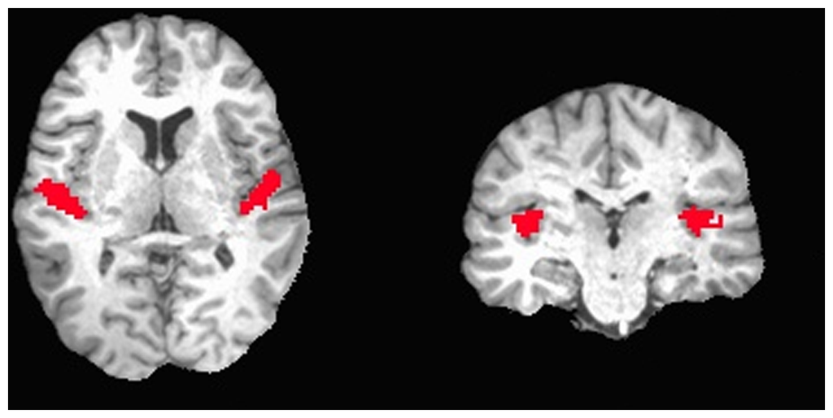

fmrifig

In reality, the analysis of the data is much more complex than ‘comparing images from two conditions’ and there exist thousands of ways to analyse the data. During this lesson, we will touch a few very basic methods, but a more thorough discussion is outside the scope. We will assume that all the data is preprocessed, which means that: - the data are corrected for motion - the data are corrected for distortions - the data from different subjects are aligned to a common template - …

### Reading and visualising fMRI data with R/neuroconductor.

After opening RStudio, we want to set our working directory to the directory we created during set up, where we can find the data:

```r
knitr::opts_knit$set(root.dir = "/Users/Joke/Documents/Onderzoek/Presentations/2017_BMSANed-Leiden/shortcourse/CNP_rest/")
```

```r
setwd("~/Desktop/fmri-validation")
```

Neuroconductor is an open-source platform for analysing neuroimaging (and other) data. It hosts multiple packages to analyse data using different software. We will mostly use its base library `neurobase`. To install, run:

```r
source("https://neuroconductor.org/neurocLite.R")
neuro_install("neurobase", release = "stable")
```

The data is located in the directory `data` in the working directory. Now we can load the data into R using the function `readnii`.

```r
library(neurobase)
basedir =
sub70083 <- readnii("sub-10159_task-rest_bold_space-MNI152NLin2009cAsym_preproc.nii.gz")
```

The function `readnii` requires one argument: the name of the file we want to read. This needs to be character string, which is why we put it in quotes. We saved the data to the variable `sub70083`. What comes out is an object of type `oro.nifti`. Essentially, it is a 4D array, with extra metadata specific to fMRI data. We can therefore apply functions that we can apply to `arrays`. Let’s look for example at the shape of our data.

```r
dim(sub70083)
```

```
## [1]  65  77  49 152
```

This shows us that the first three dimensions are `65 x 77 x 49`. These correspond to the x-, y- and z-coordinates of the brain. The fourth dimension is time, which means there are 152 time points measured.

We can also run a function from `neurobase` that only works on this type of object:

```r
check_nifti(sub70083)
```

```
## NIfTI-1 format
##   Type            : nifti
##   Data Type       : 16 (FLOAT32)
##   Bits per Pixel  : 32
##   Slice Code      : 0 (Unknown)
##   Intent Code     : 0 (None)
##   Qform Code      : 2 (Aligned_Anat)
##   Sform Code      : 1 (Scanner_Anat)
##   Dimension       : 65 x 77 x 49 x 152
##   Pixel Dimension : 3 x 3 x 4 x 2
##   Voxel Units     : Unknown
##   Time Units      : sec
```

Another interesting function is the visualisation of nifti’s:

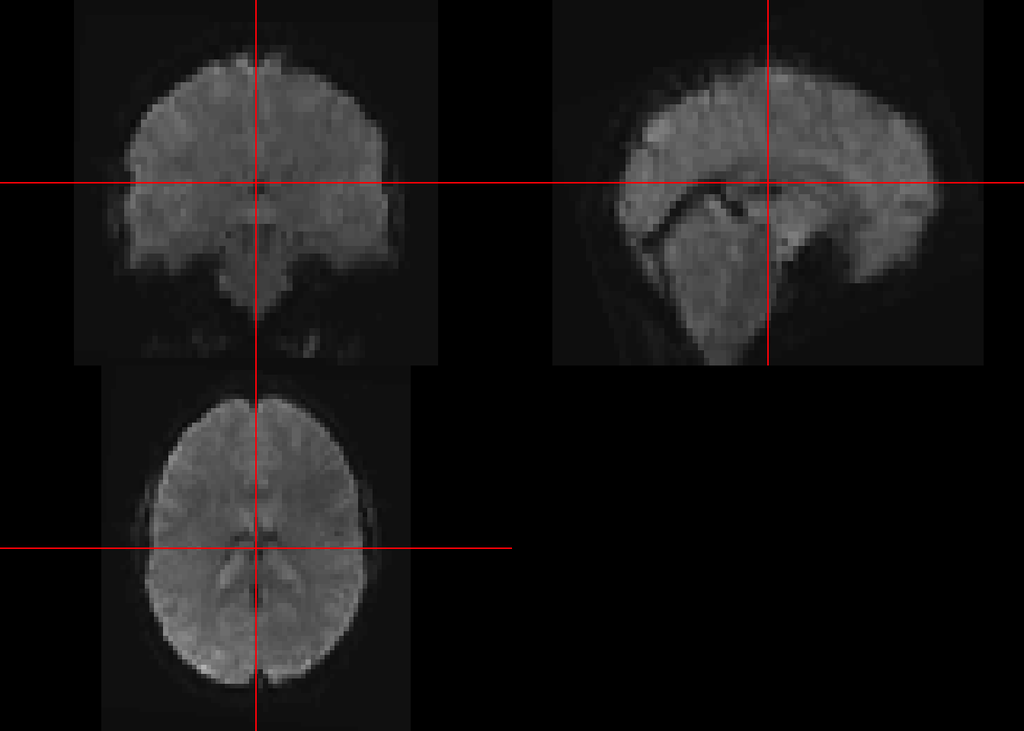

```r
orthographic(sub70083)
```

Note that we only visualise one timepoint, the first one. R will automatically show the first timepoint.

If you’re not sure about how to use a certain function, you can call for help:

```r
?orthographic
```

You will see that there are many more arguments that can be passed to the function `orthographic`. For example the argument `xyz` allows us to specify where to draw the cross-hairs. Let’s try the following:

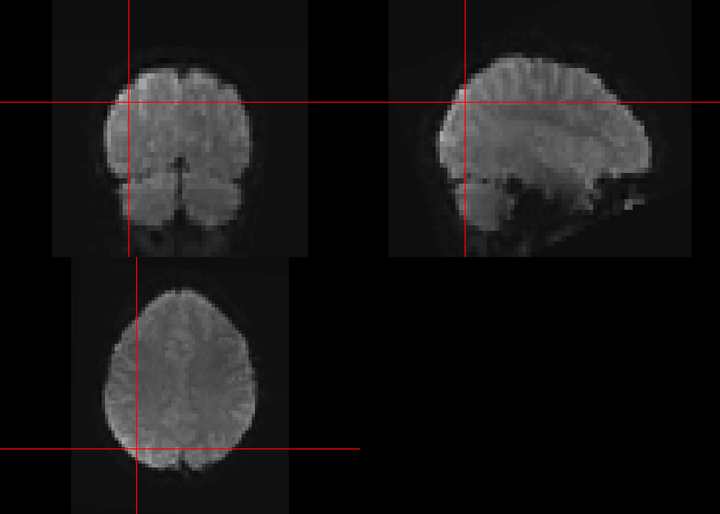

```r
orthographic(sub70083,xyz=c(20,20,30))
```

To look at the `value` of one specific point in time and space, we can use indexes. Remember our cross-hair in the figure was at the first timepoint at coordinates (20,20,30).  
The following example shows the exact value of this point in the figure at the first timepoint.

```r
sub70083[20,20,30,1]
```

```
## [1] 1148.524
```

```r
sub70083[20,20,30,]
```

```
##   [1] 1148.524 1148.461 1142.563 1141.060 1127.099 1131.675 1135.632
##   [8] 1128.941 1160.061 1161.512 1137.481 1116.822 1109.309 1109.323
##  [15] 1093.169 1110.955 1109.561 1116.910 1134.975 1118.357 1132.719
##  [22] 1150.193 1165.766 1173.594 1176.839 1142.286 1145.902 1159.892
##  [29] 1152.587 1136.450 1127.974 1148.936 1152.663 1174.247 1168.272
##  [36] 1147.255 1159.906 1184.832 1145.608 1141.148 1132.086 1137.863
##  [43] 1133.563 1143.711 1141.173 1128.889 1124.897 1132.619 1144.724
##  [50] 1153.767 1133.262 1135.230 1137.793 1165.782 1160.442 1159.418
##  [57] 1165.768 1156.091 1169.558 1182.266 1167.106 1157.483 1163.735
##  [64] 1131.992 1121.514 1111.989 1121.143 1141.684 1122.967 1126.063
##  [71] 1121.025 1138.645 1132.201 1133.171 1132.688 1134.140 1127.046
##  [78] 1127.342 1134.374 1148.151 1147.634 1145.883 1143.286 1142.210
##  [85] 1138.209 1123.161 1148.567 1149.430 1155.253 1115.818 1116.521
##  [92] 1119.263 1136.349 1144.674 1151.027 1158.472 1145.075 1124.284
##  [99] 1120.904 1129.625 1131.517 1120.666 1126.623 1109.636 1093.798
## [106] 1126.940 1126.045 1120.136 1133.749 1101.970 1098.026 1116.716
## [113] 1142.895 1143.010 1138.357 1127.057 1102.292 1122.499 1136.995
## [120] 1126.363 1137.567 1122.647 1142.551 1131.645 1125.780 1120.023
## [127] 1122.369 1132.125 1104.158 1107.103 1088.539 1116.694 1149.974
## [134] 1146.161 1140.482 1114.848 1099.089 1121.268 1141.496 1141.877
## [141] 1129.998 1106.165 1107.426 1105.125 1089.509 1103.882 1114.204
## [148] 1113.552 1096.908 1104.983 1102.881 1121.604
```

If we plot this vector, we can see how the measured signal in this voxel changes over time.

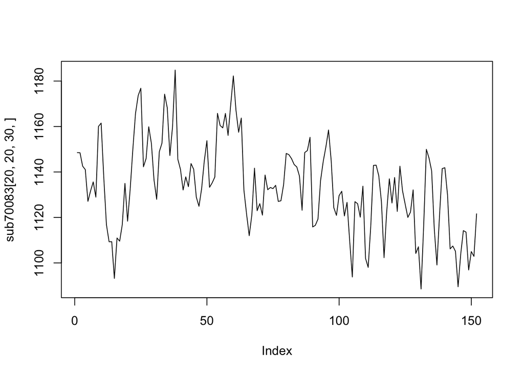

```r
plot(sub70083[20,20,30,],type='l')
```

## Exercises

> Now that we know how to read, inspect and visualise fMRI data, it’s time for some exercises ! In the data-folder, there is for each subject 3 nifti-images: - mask: sub-XXXXX_task-rest_bold_space-MNI152NLin2009cAsym_brainmask.nii.gz - rest: sub-XXXXX_task-rest_bold_space-MNI152NLin2009cAsym_preproc.nii.gz - anatomical: sub-XXXXX_T1w_preproc.nii.gz

> We have looked at the functional rest data. Now look at the anatomical scan yourself. - Read in the anatomical data. - What are the dimensions of the anatomical data? Compare with the dimensions of the rest scan. - Visualise the data. - Set the color of the cross-hairs to `blue` - Look at what the function `double_ortho` does, and use it to plot the rest scan (the first timepoint) and the anatomical scan.